# Assingnment 2

STATS 220 Semester One 2022

2022-03-30

## Introduction

In my survey, I decided to ask participants a few questions about their favorite music genre and where and how they listen to it. The purpose of these questions was to get a general idea of simply what type of music may be more popular among my participants and in what occasion people listen to music. For instance those who are fans of classical, jazz, folk, or essentially any other low tempo music are more likely to listen to music while doing tasks that require more concentration like working or studying whereas those who liked high tempo songs like pop, rock and hip hop were more likely to listen to music while doing high-intensity tasks like exercising. Streaming platforms and concerts attended in the past year were also asked to get a understanding of whether music fans rather listen to their songs online or live.

## Links to form and data

Link to form: https://forms.gle/asvXLeSG6SNyz7tH9

Link to CSV: https://docs.google.com/spreadsheets/d/1q_TNCdsIxO55d7Ba0QWRaRyY337_i1Dcl_Lx8_wJRIY/edit?resourcekey#gid=1511544416

## Analytics

| survey_completion | streaming_platform | Ls_time_min | fav_genre | concerts | Ls_setting | Ls_device |
| --- | --- | --- | --- | --- | --- | --- |
| 3/30/2022 10:43:56 | Amazon music | 120 | Hip Hop | 0 | Working/Studying | Wireless speakers |
| 3/30/2022 11:49:03 | Spotify | 120 | Rock/Metal | 0 | Workout/Exercise, In the car, Working/Studying, Relaxing/Sleeping, Cooking/Cleaning | Wireless speakers, Headphones |
| 3/30/2022 11:50:22 | Spotify | 189 | Pop | 0 | Working/Studying, Relaxing/Sleeping | laptop/Phone speakers, Headphones |
| 3/30/2022 11:54:09 | Spotify | 180 | Pop | 0 | Workout/Exercise, In the car, Working/Studying, Relaxing/Sleeping, Cooking/Cleaning | Wireless speakers, Headphones |
| 3/30/2022 12:03:25 | Spotify | 90 | Pop | 2 | Relaxing/Sleeping | Headphones |

In total, 33 participants have completed my form. The questions in the survey were based on what type of music they listen, when or how they listen to it and how it impacts their daily lives.

I have included four bar charts based on my participants results below.

```
## # A tibble: 33 x 7
##    survey_completion  streaming_platf~ Ls_time_min fav_genre concerts Ls_setting
##    <chr>              <chr>                  <dbl> <chr>        <dbl> <chr>
##  1 3/29/2022 18:14:07 Amazon music              90 Rock/Met~        3 Workout/E~
##  2 3/30/2022 10:31:08 Amazon music              50 Rock/Met~        2 Workout/E~
##  3 3/30/2022 10:43:56 Amazon music             120 Hip Hop          0 Working/S~
##  4 3/30/2022 11:49:03 Spotify                  120 Rock/Met~        0 Workout/E~
##  5 3/30/2022 11:50:22 Spotify                  189 Pop              0 Working/S~
##  6 3/30/2022 11:54:09 Spotify                  180 Pop              0 Workout/E~
##  7 3/30/2022 12:03:25 Spotify                   90 Pop              2 Relaxing/~
##  8 3/30/2022 12:11:35 None                     150 Classical        0 Workout/E~
##  9 3/30/2022 12:17:14 YouTube music             90 Classical        0 Working/S~
## 10 3/30/2022 12:34:41 Spotify                  120 Pop              0 In the ca~
## # ... with 23 more rows, and 1 more variable: Ls_device <chr>
```

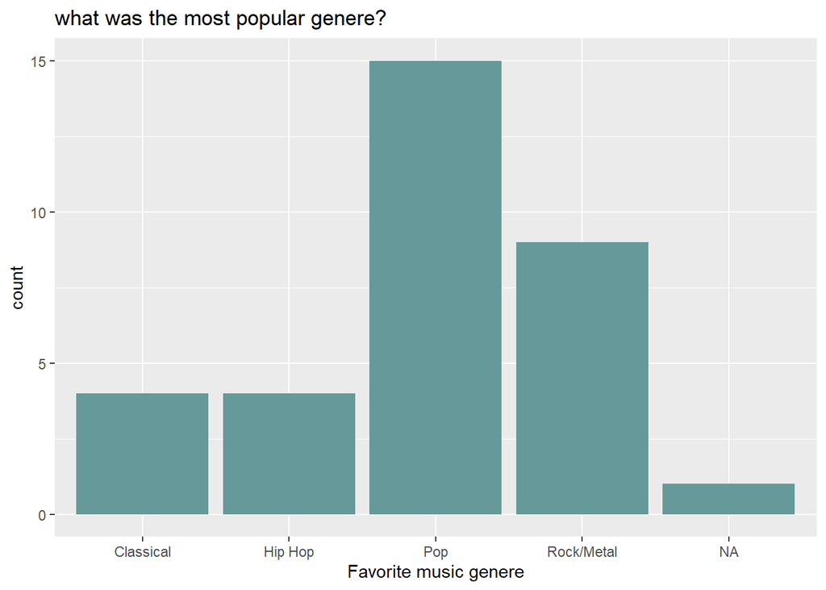

**The highest number of musical festivals/concerts attended by a person was 10 and the lowest was 0 by the majority due to lock down and pandemic.**

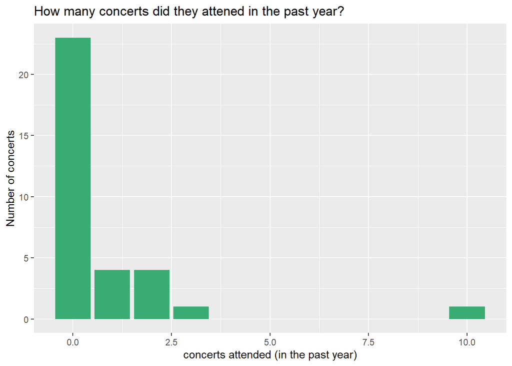

**Most participants liked listening to their music while working/studying however it may be hard to conclude that most people only listen to music while working/studying as this was a multiple choice question and participants could choose more than one option**

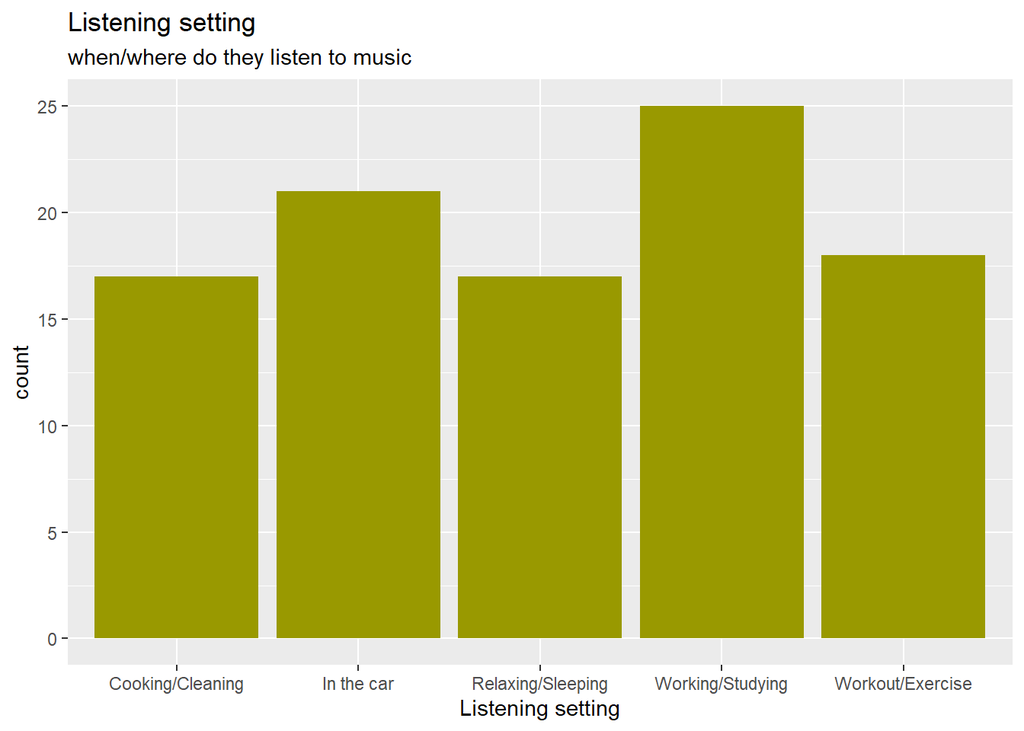

**The average amount of music participants listened to is 198.2121212 minutes per day.**

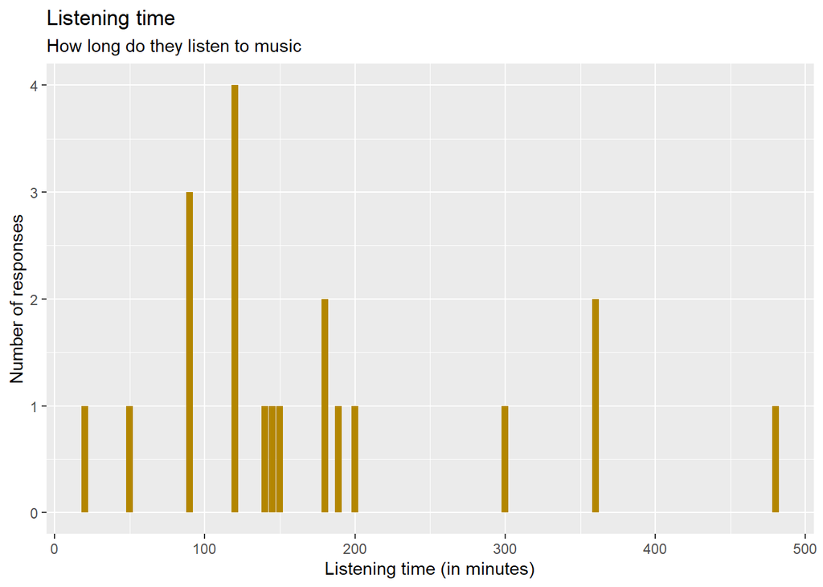

## Learning Reflection

One important thing we learned in module two was the idea of the foreign and primary keys. The primary key is one or a set of values that verifies a specific column or row is special and unique and the foreign key is the same or similar values in the primary key used in a secondary table or column to link and relate the two columns together.

The man thing that I used from module/assignment 1 was the CSS chunk to make my page more interesting by giving a background color and different fonts to it. However, I also used a few small techniques from my last assignment such as `code_folding = hide` (which hides the codes and makes the HTML look tidy), added a `highlight: zenburn` (gives a style and highlight to the syntax), and making my text bold by `<b>` and `</b>` in certain places to make it less boring and draw the readers attention and lastly some function like pipe and changing the variable name (`<-`) which is essential for the code to run.

Data technologies are rapidly growing and developing and the more you know about it the more you’ll know about today’s world and the latest technologies. I am curious and excited to learn about Perspective analysis, complex systems, Artificial intelligence and generally more about different types of data analyses in more depth in this course and other Stats/Data technologies courses.

Thanks for viewing my HTML, This program was last knitted on 2023-02-27 :-)